# Exercises_for_Boosting

MCA Technology Solutions Private Limited was established in 2015 in Bangalore with an objective to integrate analytics and technology with business. MCA Technology Solutions helped its clients in areas such as customer intelligence, forecasting, optimization, risk assessment, web analytics, and text mining, and cloud solutions. Risk assessment vertical at MCA technology solutions focuses on problems such as fraud detection and credit scoring. Sachin Kumar, Director at MCA Technology Solutions, Bangalore was approached by one of his clients, a commercial earnings, to assist them in detecting earning manipulators among the earnings’s customers. The earnings provided business loans to small and medium enterprises and the value of loan ranged from INR 10 million to 500 million ($1 = INR 66.82, August 16, 2016). The earnings suspected that their customers may be involved in earnings’ manipulations to increase their chance of securing a loan.

The data is available in the file “Earnings Manipulation 220.csv”.

Description of the columns is given in Table. In this table

- netPPE is net Property, Plant, and Equipment. Property Plant and Equipment is the value of

all buildings, land, furniture, and other physical capital that a business has purchased to run a business.

- Subscript (t) means value in the current year financial statement and subscript (t - 1) means the

value in the previous year financial statement.

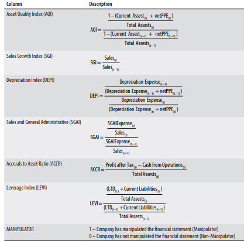

```python
import pandas as pd
earnings_df = pd.read_csv( 'Earnings Manipulation 220.csv')
earnings_df.head()
```

|  | Company Name | Year Ending | DSRI | GMI | AQI | SGI | DEPI | SGAI | ACCR | LEVI | MANIPULATOR |
| --- | --- | --- | --- | --- | --- | --- | --- | --- | --- | --- | --- |
| 0 | 1 | 31-03-2014 | 1.624742 | 1.128927 | 7.185053 | 0.366211 | 1.381519 | 1.624145 | -0.166809 | 1.161082 | 1 |
| 1 | 2 | 31-03-2009 | 1.000000 | 1.606492 | 1.004988 | 13.081433 | 0.400000 | 5.198207 | 0.060475 | 0.986732 | 1 |
| 2 | 3 | 31-03-2008 | 1.000000 | 1.015607 | 1.241389 | 1.475018 | 1.169353 | 0.647671 | 0.036732 | 1.264305 | 1 |
| 3 | 4 | 31-03-2014 | 1.486239 | 1.000000 | 0.465535 | 0.672840 | 2.000000 | 0.092890 | 0.273434 | 0.680975 | 1 |
| 4 | 5 | 31-03-2010 | 1.000000 | 1.369038 | 0.637112 | 0.861346 | 1.454676 | 1.741460 | 0.123048 | 0.939047 | 1 |

```python
earnings_df.columns
```

```
Index(['Company Name', 'Year Ending', 'DSRI', 'GMI', 'AQI', 'SGI', 'DEPI',
       'SGAI', 'ACCR', 'LEVI', 'MANIPULATOR'],
      dtype='object')
```

```python
earnings_df.info()
```

```
<class 'pandas.core.frame.DataFrame'>
RangeIndex: 220 entries, 0 to 219
Data columns (total 11 columns):
 #   Column        Non-Null Count  Dtype
---  ------        --------------  -----
 0   Company Name  220 non-null    int64
 1   Year Ending   220 non-null    object
 2   DSRI          220 non-null    float64
 3   GMI           220 non-null    float64
 4   AQI           220 non-null    float64
 5   SGI           220 non-null    float64
 6   DEPI          220 non-null    float64
 7   SGAI          220 non-null    float64
 8   ACCR          220 non-null    float64
 9   LEVI          220 non-null    float64
 10  MANIPULATOR   220 non-null    int64
dtypes: float64(8), int64(2), object(1)
memory usage: 19.0+ KB
```

```python
earnings_df.MANIPULATOR.unique()
```

```
array([1, 0])
```

```python
earnings_df.MANIPULATOR.value_counts()
```

```
MANIPULATOR
0    181
1     39
Name: count, dtype: int64
```

```python
X = earnings_df.drop(columns=['Company Name', 'Year Ending', 'MANIPULATOR'])
y = earnings_df['MANIPULATOR']
```

1. How many cases of manipulators versus non-manipulators are there in the dataset? Draw a bar plot

to depict.

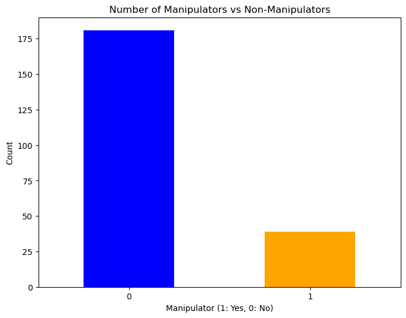

```python
import matplotlib.pyplot as plt
manipulator_counts = earnings_df.MANIPULATOR.value_counts()
plt.figure(figsize=(8, 6))
manipulator_counts.plot(kind='bar', color=['blue', 'orange'])
plt.title('Number of Manipulators vs Non-Manipulators')
plt.xlabel('Manipulator (1: Yes, 0: No)')
plt.ylabel('Count')
plt.xticks(rotation=0)
plt.show()
```

2. The number of cases of manipulators are very less compared to non-manipulators. Use upsampling

technique to create a balance dataset.

```python
data_combined = pd.concat([X, y], axis=1)
majority_class = data_combined[data_combined['MANIPULATOR'] == 0]
minority_class = data_combined[data_combined['MANIPULATOR'] == 1]
minority_upsampled = resample(minority_class, replace=True, n_samples=len(majority_class), random_state=42)
new_earnings_df = pd.concat([majority_class, minority_upsampled])
```

```python
X = new_earnings_df.drop(columns=['MANIPULATOR'])
Y = new_earnings_df['MANIPULATOR']
```

```python
from sklearn.model_selection import train_test_split
train_X, test_X, train_y, test_y = train_test_split( X,Y,test_size = 0.3,random_state = 42 )
```

4. Build the following models using balanced dataset and compare the accuracies. Use ROC AUC score

for accuracy.

- Random Forest
- AdaBoost with Logistic Regression as base estimator
- Gradient Boosting

```python
from sklearn.ensemble import RandomForestClassifier
radm_clf = RandomForestClassifier(max_depth=10, n_estimators=10)
radm_clf.fit(train_X, train_y)
```

```
RandomForestClassifier(max_depth=10, n_estimators=10)
```

```python
from sklearn import metrics
import matplotlib.pyplot as plt
import seaborn as sn
%matplotlib inline
def draw_roc_curve( model, test_X, test_y ):
 test_results_df = pd.DataFrame( { 'actual': test_y } )
 test_results_df = test_results_df.reset_index()
 predict_proba_df = pd.DataFrame( model.predict_proba( test_X ) )
 test_results_df['MANIPULATOR'] = predict_proba_df.iloc[:,1:2]
 fpr, tpr, thresholds = metrics.roc_curve( test_results_df.actual,test_results_df.MANIPULATOR, drop_intermediate = False )
 auc_score = metrics.roc_auc_score( test_results_df.actual, test_results_df.MANIPULATOR )
 plt.figure(figsize=(8, 6))
 plt.plot( fpr, tpr, label='ROC curve (area = %0.2f)' % auc_score )
 plt.plot([0, 1], [0, 1], 'k--')
 plt.xlim([0.0, 1.0])
 plt.ylim([0.0, 1.05])
 plt.xlabel('False Positive Rate or [1 - True Negative Rate]')
 plt.ylabel('True Positive Rate')
 plt.title('Receiver operating characteristic')
 plt.legend(loc="lower right")
 plt.show()
 return auc_score, fpr, tpr, thresholds
```

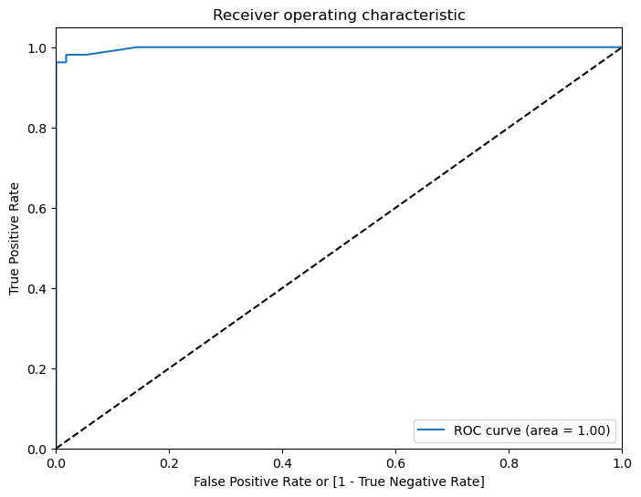

```python
_, _, _, _ = draw_roc_curve(radm_clf, test_X, test_y)
```

```python
from sklearn.ensemble import AdaBoostClassifier
from sklearn.linear_model import LogisticRegression
logreg_clf = LogisticRegression()
ada_clf = AdaBoostClassifier (logreg_clf, n_estimators=50)
ada_clf.fit(train_X, train_y)
```

```
AdaBoostClassifier(estimator=LogisticRegression())
```

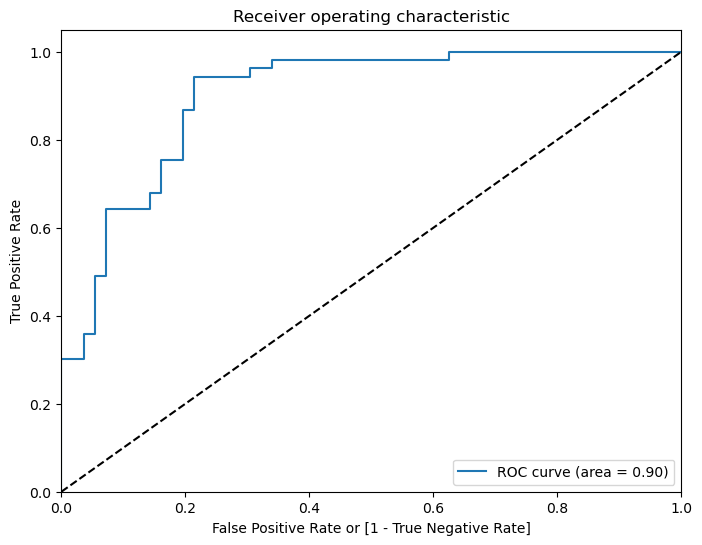

```python
_, _, _, _ = draw_roc_curve(ada_clf, test_X, test_y)
```

```python
from sklearn.ensemble import GradientBoostingClassifier
gboost_clf = GradientBoostingClassifier(n_estimators=500, max_depth=10)
gboost_clf.fit (train_X, train_y)
```

```
GradientBoostingClassifier(max_depth=10, n_estimators=500)
```

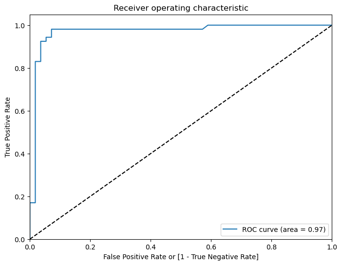

```python
_, _, _, _ = draw_roc_curve(gboost_clf, test_X, test_y)
```

5. The number of cases of manipulators are very less compared to non-manipulators. Use downsampling technique to create a balance dataset.

```python
data_combined = pd.concat([X, y], axis=1)
majority_class = data_combined[data_combined['MANIPULATOR'] == 0]
minority_class = data_combined[data_combined['MANIPULATOR'] == 1]
majority_downsampled = majority_class.sample(len(minority_class), random_state=42)
new1_earnings_df = pd.concat([majority_downsampled, minority_class])
```

```python
X = new1_earnings_df.drop(columns=['MANIPULATOR'])
Y = new1_earnings_df['MANIPULATOR']
from sklearn.model_selection import train_test_split
train_X, test_X, train_y, test_y = train_test_split( X,Y,test_size = 0.3,random_state = 42 )
```

```python
from sklearn.ensemble import RandomForestClassifier
radm_clf = RandomForestClassifier(max_depth=10, n_estimators=10)
radm_clf.fit(train_X, train_y)
```

```
RandomForestClassifier(max_depth=10, n_estimators=10)
```

```python
from sklearn import metrics
import matplotlib.pyplot as plt
import seaborn as sn
%matplotlib inline
def draw_roc_curve( model, test_X, test_y ):
 test_results_df = pd.DataFrame( { 'actual': test_y } )
 test_results_df = test_results_df.reset_index()
 predict_proba_df = pd.DataFrame( model.predict_proba( test_X ) )
 test_results_df['MANIPULATOR'] = predict_proba_df.iloc[:,1:2]
 fpr, tpr, thresholds = metrics.roc_curve( test_results_df.actual,test_results_df.MANIPULATOR, drop_intermediate = False )
 auc_score = metrics.roc_auc_score( test_results_df.actual, test_results_df.MANIPULATOR )
 plt.figure(figsize=(8, 6))
 plt.plot( fpr, tpr, label='ROC curve (area = %0.2f)' % auc_score )
 plt.plot([0, 1], [0, 1], 'k--')
 plt.xlim([0.0, 1.0])
 plt.ylim([0.0, 1.05])
 plt.xlabel('False Positive Rate or [1 - True Negative Rate]')
 plt.ylabel('True Positive Rate')
 plt.title('Receiver operating characteristic')
 plt.legend(loc="lower right")
 plt.show()
 return auc_score, fpr, tpr, thresholds
```

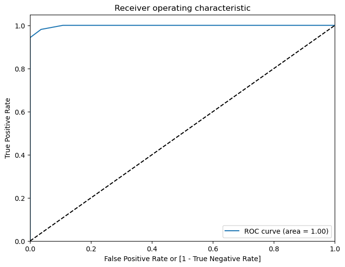

```python
_, _, _, _ = draw_roc_curve(radm_clf, test_X, test_y)
```

```python
from sklearn.ensemble import AdaBoostClassifier
from sklearn.linear_model import LogisticRegression
logreg_clf = LogisticRegression()
ada_clf = AdaBoostClassifier (logreg_clf, n_estimators=50)
ada_clf.fit(train_X, train_y)
```

```
AdaBoostClassifier(estimator=LogisticRegression())
```

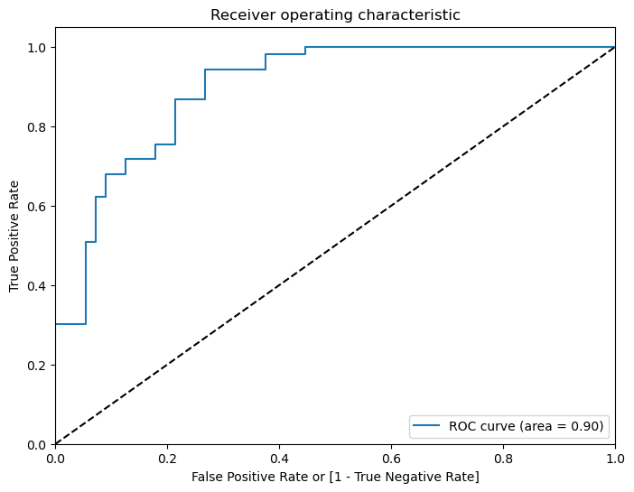

```python
_, _, _, _ = draw_roc_curve(ada_clf, test_X, test_y)
```

```python
from sklearn.ensemble import GradientBoostingClassifier
gboost_clf = GradientBoostingClassifier(n_estimators=500, max_depth=10)
gboost_clf.fit (train_X, train_y)
```

```
GradientBoostingClassifier(max_depth=10, n_estimators=500)
```

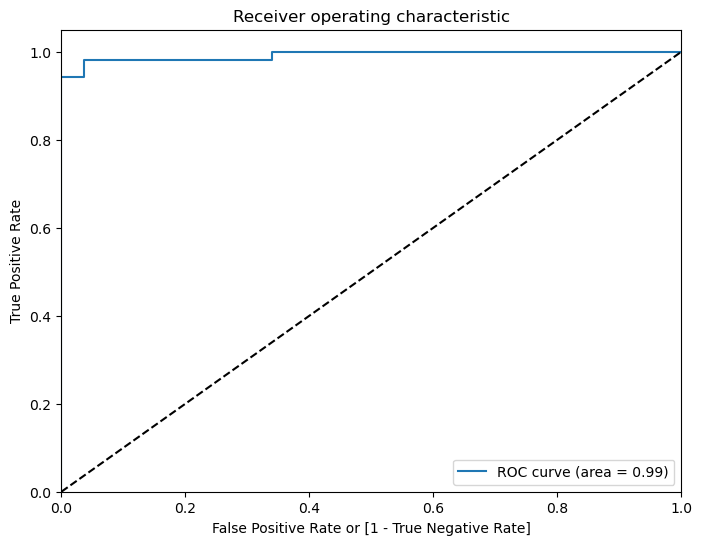

```python
_, _, _, _ = draw_roc_curve(gboost_clf, test_X, test_y)
```

```python
from sklearn.model_selection import cross_val_score
import numpy as np
gboost_clf = GradientBoostingClassifier(n_estimators=500, max_depth=10)
cv_scores = cross_val_score(gboost_clf, train_X, train_y, cv=10, scoring = 'roc_auc')
print(cv_scores)
print("Mean Accuracy: ", np.mean(cv_scores), "with standard deviation of: ", np.std(cv_scores))
```

```
[1.         1.         0.95266272 0.98076923 1.         0.96153846
 0.98076923 1.         1.         1.        ]
Mean Accuracy:  0.9875739644970414 with standard deviation of:  0.01707538938521666
```

Report the precision and recall for manipulator and non-manipulator cases.

```python
pred_y_radm = radm_clf.predict(test_X)
print(metrics.classification_report(test_y, pred_y_radm))
```

```
              precision    recall  f1-score   support

           0       0.98      0.95      0.96        56
           1       0.95      0.98      0.96        53

    accuracy                           0.96       109
   macro avg       0.96      0.96      0.96       109
weighted avg       0.96      0.96      0.96       109
```

```python
pred_y_ada = ada_clf.predict(test_X)
print(metrics.classification_report(test_y, pred_y_ada))
```

```
              precision    recall  f1-score   support

           0       0.72      0.86      0.78        56
           1       0.81      0.64      0.72        53

    accuracy                           0.75       109
   macro avg       0.76      0.75      0.75       109
weighted avg       0.76      0.75      0.75       109
```

```python
pred_y_gboost = gboost_clf.predict(test_X)
print(metrics.classification_report(test_y, pred_y_gboost))
```

```
              precision    recall  f1-score   support

           0       0.98      0.84      0.90        56
           1       0.85      0.98      0.91        53

    accuracy                           0.91       109
   macro avg       0.92      0.91      0.91       109
weighted avg       0.92      0.91      0.91       109
```